# Robust SSA methods

A. Tretyakova

5 декабря 2019 г

Пусть имеется ряд
$$x_n= n e^{an} \sin(2\pi\omega n) + Ae^{an}\varepsilon_n,$$
где $\varepsilon_i\sim N(0,1)$. Возьмем уже имеющийся сигнал из примера, добавим к нему шум, получим ряд длины $N=240$:
$$x_n=n e^{4n/N} \sin(2\pi n/30) + Ae^{4n/N}\varepsilon_n,$$
где $\varepsilon_i\sim N(0,1)$.

Будем добавлять 5% выбросов размера $1.5x_i$.

Для того, чтобы пользоваться полученной формулой для параметра $\alpha$
$$\alpha=\frac{\sqrt{2}\pi}{2}erf^{-1}(\gamma),$$
надо доказать, что $r^*=|\frac{r}{\sigma}|\sim N_h(\frac{\pi}{2})$, где $R=\{r_{i}\}_{i=1}^N$ — остатки, $\sigma=(\sigma_1,\ldots,\sigma_N)$ — тренд из $|R|$.

Если сигнал $n e^{an} \sin(2\pi\omega n)$ отделим от шума, то остатки $R=Ae^{an}\varepsilon_n$.

Известно, что если $\varepsilon \sim N(0,\sigma_\varepsilon^2),$ то $\mathbb{E}|\varepsilon| = \sigma_\varepsilon \sqrt{\frac{2}{\pi}}$, $\mathbb{D}|\varepsilon| = \sigma_\varepsilon^2 (1-\frac{2}{\pi}).$

$$\mathbb{E}|R| = Ae^{an} \mathbb{E} |\varepsilon| = Ae^{an}\sqrt{\frac{2}{\pi}}.$$
Выпишем нормированные остатки: $\frac{r}{\sigma} = \frac{Ae^{an}\varepsilon}{Ae^{an}\mathbb{E}|\varepsilon|} \sim N(0,\frac{1}{\frac{2}{\pi}}) = N(0,\frac{\pi}{2}).$

Тогда получим следующее: $|\frac{r}{\sigma}| \sim N_h(\frac{\pi}{2})$ по определению полунормального распределения.

График ряда без выбросов:

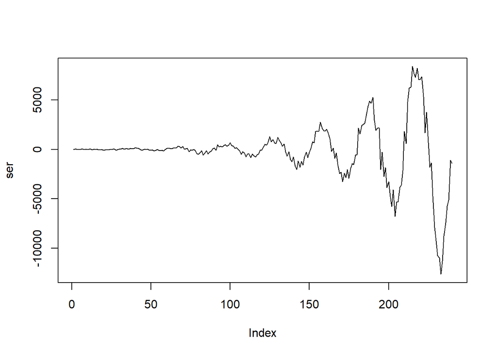

```r
N<-240
sig <- (1:N)*exp(4*(1:N)/N)*sin(2*pi*(1:N)/30)

sig.outl<-sig
outlier.seq<-sample(1:(N),N*0.05)
sig.outl[outlier.seq]<-sig.outl[outlier.seq]+0*sig.outl[outlier.seq]
ser<-sig.outl+30*exp(4*(1:N)/N)*rnorm(N)
real.trend<-30*exp(4*(1:N)/N)
plot(ser,type='l')
```

График ряда с 5% выбросов:

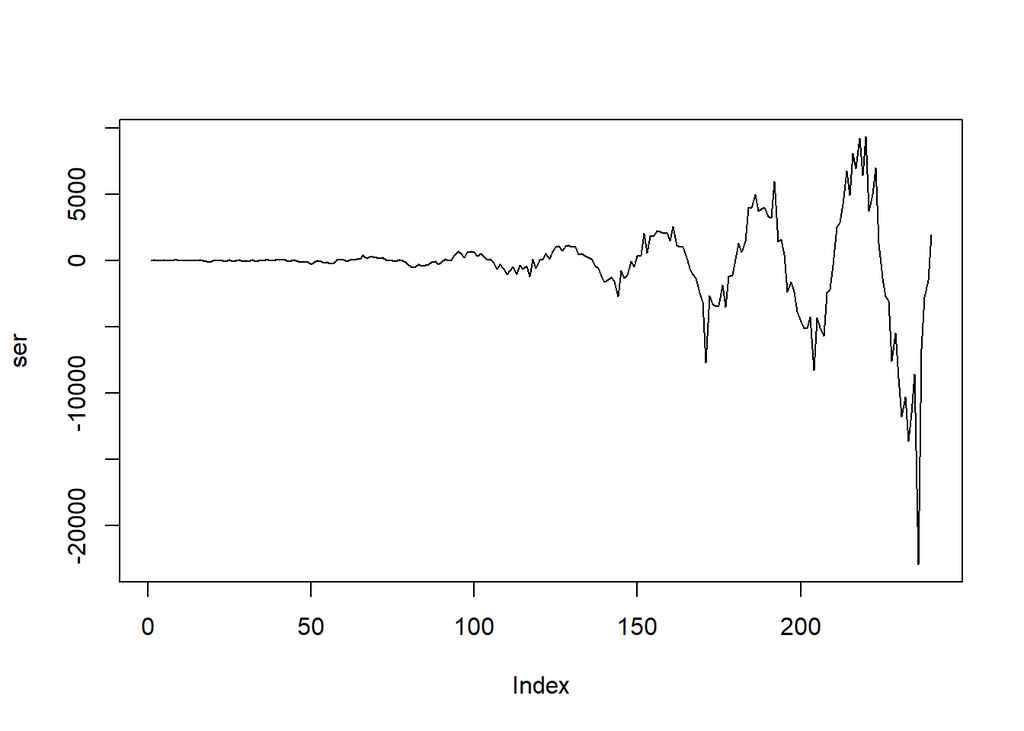

```r
sig.outl<-sig
outlier.seq<-sample(1:(N),N*0.05)
sig.outl[outlier.seq]<-sig.outl[outlier.seq]+1.5*sig.outl[outlier.seq]
ser<-sig.outl+30*exp(4*(1:N)/N)*rnorm(N)

plot(ser,type='l')
```

```r
X<-hankel(ser, L=120)

eps<-1e-8
eps1<-1e-5
maxITER<-20
maxiter<-10
```

Проблемы могут быть две — либо плохо выделится тренд из ряда модулей остатков, либо отсутствие разделимости между сигналом и шумом.

Попробуем два варианта — выделять тренд скользящей медианой, методом loess, и для сравнения добавим истинный тренд остатков.

График модуля из остатков и выделение тренда разными способами (в случае 5% выбросов):

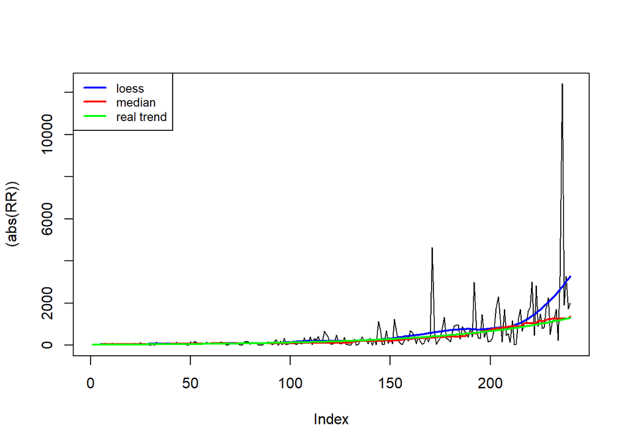

```r
  M<-X
  m<-nrow(M)
  n<-ncol(M)
  initial<-svd(M)
  k<-2
  U<-initial$u[1:nrow(initial$u),1:k]
  Lambda<-initial$d[1:k]
  V<-initial$v[1:nrow(initial$v),1:k]
  U<-U%*%diag(Lambda)
  alpha<-4.046
  ITER<-0
  iter<-0

    R<-M-U%*%t(V)
    r<-as.vector(t(R))
    RR<-hankL1(R)
    loessMod30 <- loess(abs(RR) ~ c(1:length(abs(RR))), span=0.30)
    sigma <- predict(loessMod30)

    sigma1<-runmed(abs(RR),61)
    sigma1[(N-30):N]<-calc.ends(abs(RR),30)

    sigma2<-real.trend*sqrt(2/pi)
    plot((abs(RR)), type='l')
    lines(sigma, type='l',col='blue',lw=2)
    lines(sigma1, type='l',col='red',lw=2)
    lines(sigma2, type='l',col='green',lw=2)
    legend('topleft', c("loess", "median", "real trend"),
       col=c("blue","red","green"), lty=1, cex=0.8, lw=2)
```

```r
    RR.trmatrix<-hankel(RR,L=120)
    sigma.trmatrix<-hankel(sigma,L=120)
    sigma.trmatrix1<-hankel(sigma1,L=120)
    sigma.trmatrix2<-hankel(sigma2,L=120)
```

[output not shown]

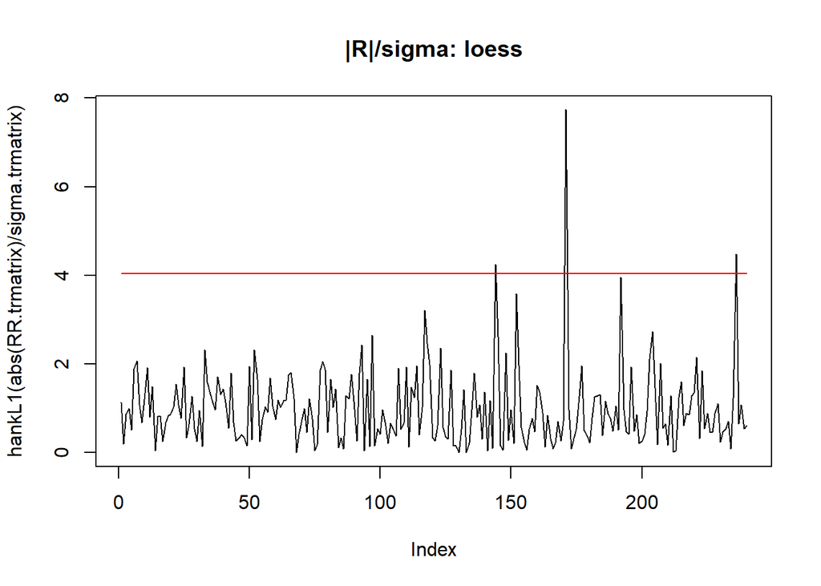

```r
    plot(hankL1(abs(RR.trmatrix)/sigma.trmatrix), type='l')
    lines(rep(alpha,N),col='red')
    title(main='|R|/sigma: loess')
```

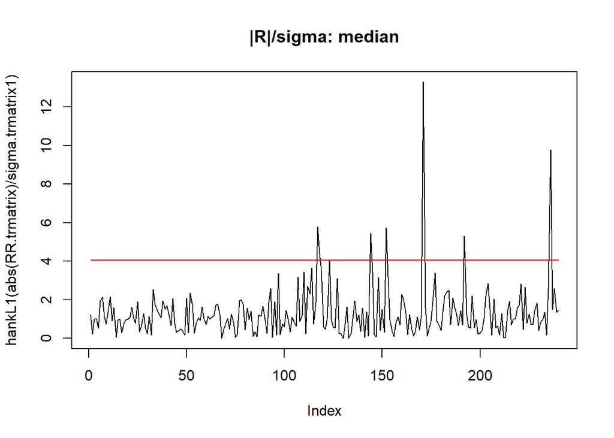

```r
    plot(hankL1(abs(RR.trmatrix)/sigma.trmatrix1), type='l')
    lines(rep(alpha,N),col='red')
    title(main='|R|/sigma: median')
```

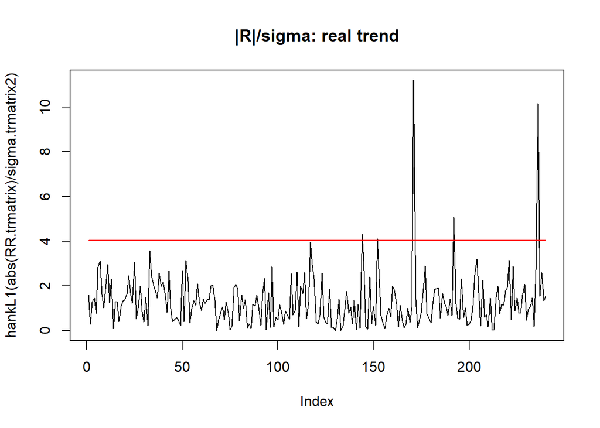

```r
    plot(hankL1(abs(RR.trmatrix)/sigma.trmatrix2), type='l')
    lines(rep(alpha,N),col='red')
    title(main='|R|/sigma: real trend')
```

Полученные веса:

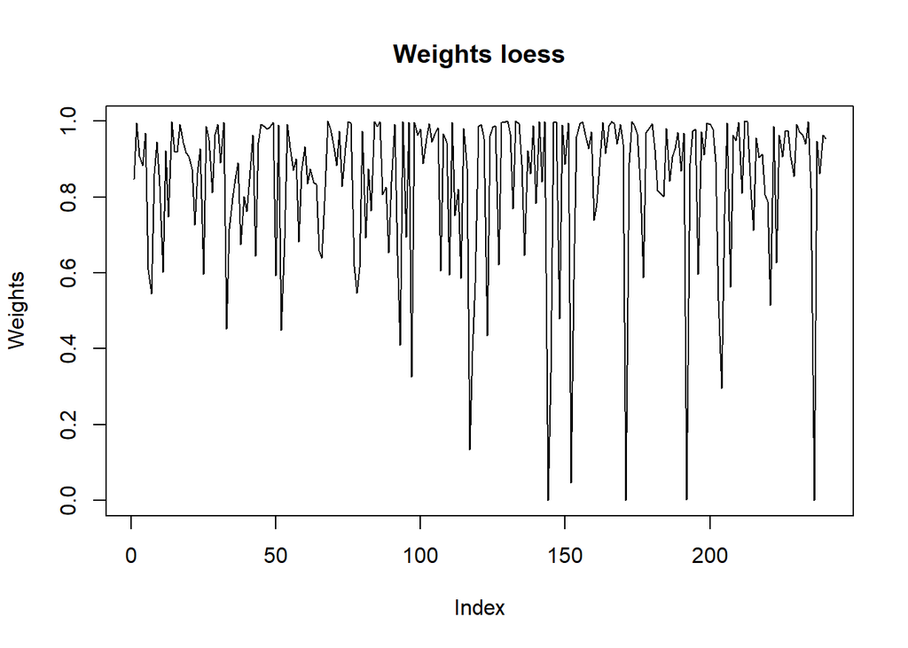

```r
    W<-weights(RR.trmatrix,sigma.trmatrix,alpha,m,n)
    WW<-hankL1(W)
    Weights<-WW
    plot(Weights, type='l')
    title(main='Weights loess')
```

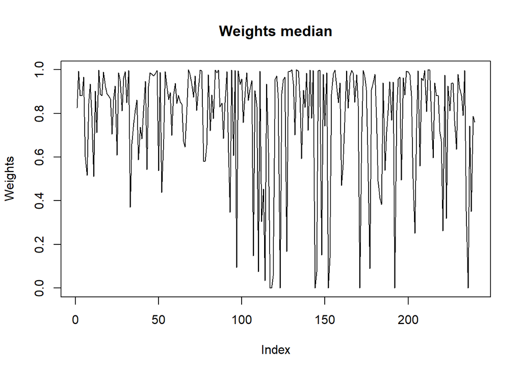

```r
     W<-weights(RR.trmatrix,sigma.trmatrix1,alpha,m,n)
    WW<-hankL1(W)
    Weights<-WW
    plot(Weights, type='l')
    title(main='Weights median')
```

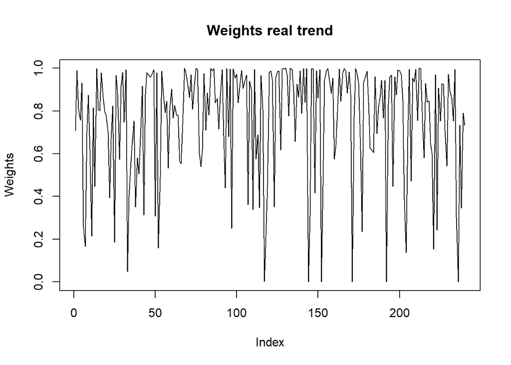

```r
     W<-weights(RR.trmatrix,sigma.trmatrix2,alpha,m,n)
    WW<-hankL1(W)
    Weights<-WW
    plot(Weights, type='l')
    title(main='Weights real trend')
```

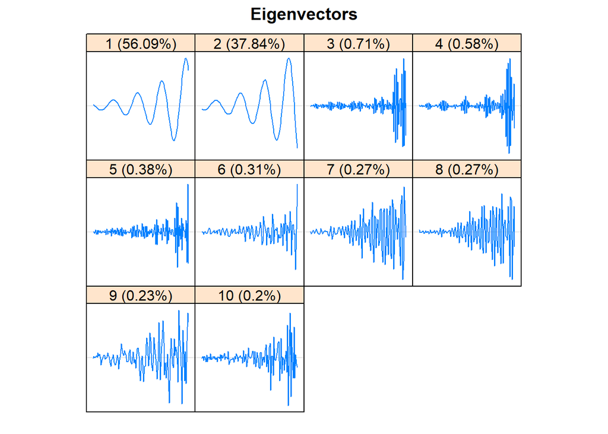

```r
sig <- (1:N)*exp(4*(1:N)/N)*sin(2*pi*(1:N)/30)
ser<-sig+30*exp(4*(1:N)/N)*rnorm(N)

 s <- ssa(ser, L = 120)
 plot(s, type = "vectors",idx = 1:10)
```

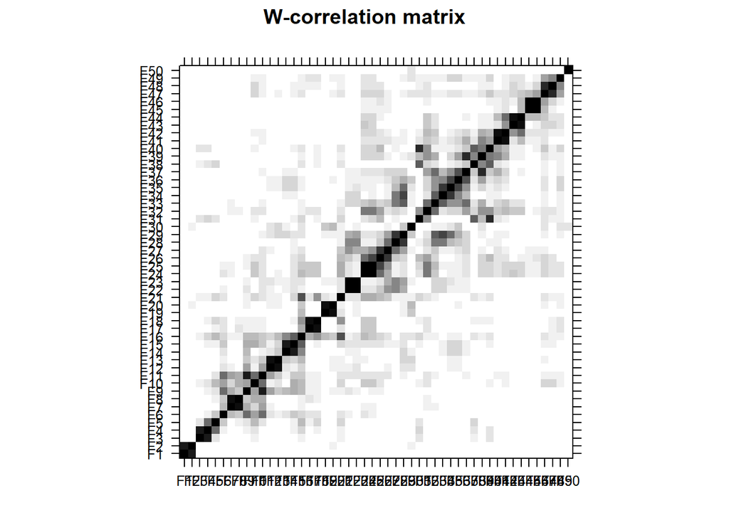

```r
 plot(wcor(s))
```

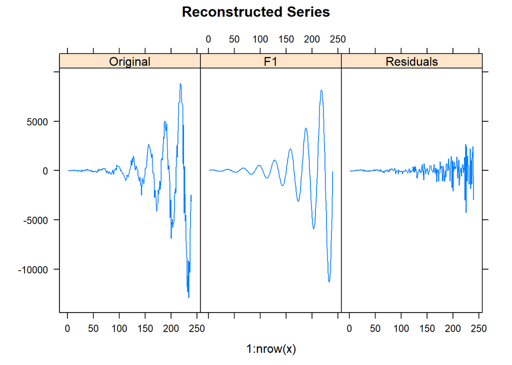

```r
 rec <- reconstruct(s, groups = list(c(1:2)))
 plot(rec, add.residuals = TRUE, add.original = TRUE,
     plot.method = "xyplot", superpose = TRUE, auto.key = list(columns = 2))
```

Для начала попробуем без выбросов.

```r
M <- 1

MSE.SSA <- rep(0,M)
MSE.L1svd <- rep(0,M)
MSE <- rep(0,M)
MSE1 <- rep(0,M)
MSE2 <- rep(0,M)

MAD.SSA <- rep(0,M)
MAD.L1svd <- rep(0,M)
MAD <- rep(0,M)
MAD1 <- rep(0,M)
MAD2 <- rep(0,M)


for(k in 1:M)
{

  # Without outliers

sig <- (1:N)*exp(4*(1:N)/N)*sin(2*pi*(1:N)/30)

sig.outl<-sig
outlier.seq<-sample(1:(N),N*0.05)
sig.outl[outlier.seq]<-sig.outl[outlier.seq]+0*sig.outl[outlier.seq]
ser<-sig.outl+30*exp(4*(1:N)/N)*rnorm(N)

#plot(ser,type='l')
X<-hankel(ser, L=120)

  ############################### #SSA120.3 ##############################

  s <- ssa(ser, L = 120)
  rec <- reconstruct(s, groups = list(c(1:2)))

  # plot(s, type = "vectors",idx = 1:10)
  # plot(rec, add.residuals = TRUE, add.original = TRUE,
  #  plot.method = "xyplot", superpose = TRUE, auto.key = list(columns = 2))
  #plot(wcor(s))
  trend.season <- rec$F1

  ############################# #pcaL1(120.3)###############################
  X<-hankel(ser,L=120)
  s.L1svd<-l1pca(X,center=FALSE,projections="l1",projDim=2)

  Pr<-s.L1svd$projPoints
  Pr.L1svd<-hankL1(Pr)

  ###################### WLS ########################
  Pr<-QR_WLS(X,2,'loess')
  Pr0<-hankL1(Pr)

  Pr<-QR_WLS(X,2,'median')
  Pr1<-hankL1(Pr)

  Pr<-QR_WLS(X,2,'real')
  Pr2<-hankL1(Pr)


  #MSE
  MSE.SSA[k] <- mean((sig - trend.season)[1:N]^2)
  MSE.L1svd[k] <- mean((sig - Pr.L1svd)[1:N]^2)
  MSE[k] <- mean((sig - Pr0)[1:N]^2)
  MSE1[k] <- mean((sig - Pr1)[1:N]^2)
  MSE2[k] <- mean((sig - Pr2)[1:N]^2)

  #MAD
  MAD.SSA[k] <- mean(abs((sig - trend.season)[1:N]))
  MAD.L1svd[k] <- mean(abs((sig - Pr.L1svd)[1:N]))
  MAD[k] <- mean(abs((sig - Pr0)[1:N]))
  MAD1[k] <- mean(abs((sig - Pr1)[1:N]))
  MAD2[k] <- mean(abs((sig - Pr2)[1:N]))

}

RMSE.SSA<-sqrt(mean(MSE.SSA))
RMSE.L1svd<-sqrt(mean(MSE.L1svd))
RMSE<-sqrt(mean(MSE))
RMSE1<-sqrt(mean(MSE1))
RMSE2<-sqrt(mean(MSE2))

MAD.SSA<-mean(MAD.SSA)
MAD.L1svd<-mean(MAD.L1svd)
MAD<-mean(MAD)
MAD1<-mean(MAD1)
MAD2<-mean(MAD2)

RMSE.SSA #ошибка SSA
```

```
## [1] 237.5186
```

```r
RMSE.L1svd #ошибка последовательного метода L1svd
```

```
## [1] 275.6847
```

```r
RMSE #ошибка IRLS с выделением тренда из модуля остатков с помощью loess
```

```
## [1] 250.6196
```

```r
RMSE1 #ошибка IRLS с выделением тренда из модуля остатков с помощью скользящей медианы
```

```
## [1] 320.3081
```

```r
RMSE2 #ошибка IRLS со знанием реального тренда из модуля остатков
```

```
## [1] 252.3008
```

Посмотрим на восстановление сигнала всеми методами.

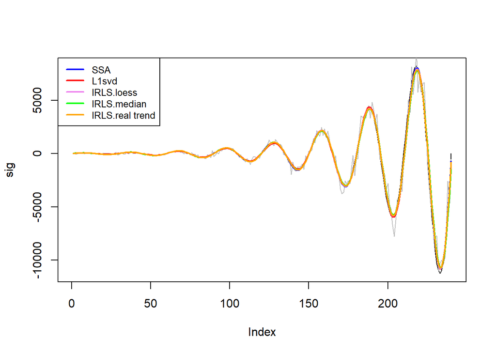

```r
plot(sig,type='l')
lines(ser,col='gray')
lines(trend.season,type='l',col='blue',lw=2)
lines(Pr.L1svd,type='l',col='red',lw=2)
lines(Pr0,type='l',col='violet',lw=2)
lines( Pr1,type='l',col='green',lw=2)
lines( Pr2,type='l',col='orange',lw=2)
legend('topleft', c("SSA","L1svd","IRLS.loess", "IRLS.median", "IRLS.real trend"),
       col=c("blue","red","violet","green","orange"), lty=1, cex=0.8, lw=2)
```

Конец ряда поближе:

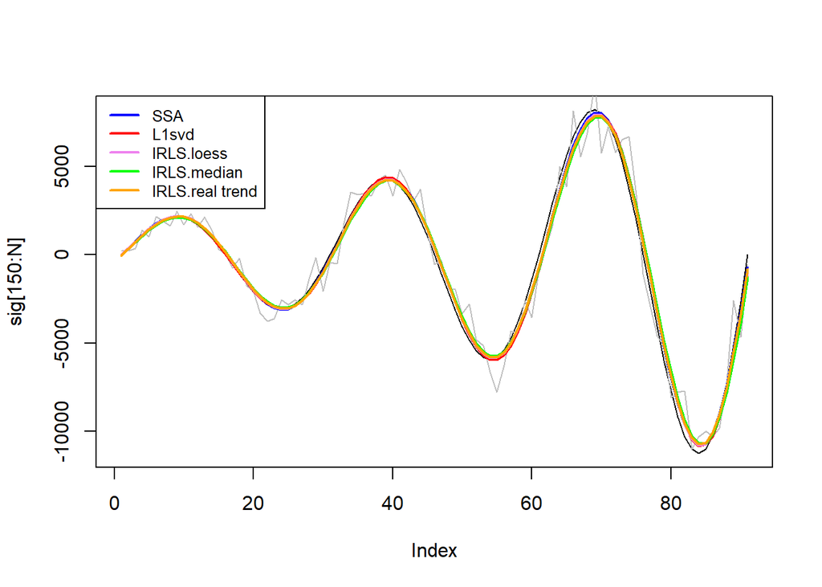

```r
plot(sig[150:N],type='l')
lines(ser[150:N],col='gray')
lines(trend.season[150:N],type='l',col='blue',lw=2)
lines(Pr.L1svd[150:N],type='l',col='red',lw=2)
lines(Pr0[150:N],type='l',col='violet',lw=2)
lines( Pr1[150:N],type='l',col='green',lw=2)
lines( Pr2[150:N],type='l',col='orange',lw=2)
legend('topleft', c("SSA","L1svd","IRLS.loess", "IRLS.median", "IRLS.real trend"),
       col=c("blue","red","violet","green","orange"), lty=1, cex=0.8, lw=2)
```

С 5% выбросов:

```r
M <- 1

MSE.SSA <- rep(0,M)
MSE.L1svd <- rep(0,M)
MSE <- rep(0,M)
MSE1 <- rep(0,M)
MSE2 <- rep(0,M)

MAD.SSA <- rep(0,M)
MAD.L1svd <- rep(0,M)
MAD <- rep(0,M)
MAD1 <- rep(0,M)
MAD2 <- rep(0,M)


for(k in 1:M)
{


sig <- (1:N)*exp(4*(1:N)/N)*sin(2*pi*(1:N)/30)

sig.outl<-sig
outlier.seq<-sample(1:(N),N*0.05)
sig.outl[outlier.seq]<-sig.outl[outlier.seq]+1.5*sig.outl[outlier.seq]
ser<-sig.outl+30*exp(4*(1:N)/N)*rnorm(N)

#plot(ser,type='l')
X<-hankel(ser, L=120)

  ############################### #SSA120.3 ##############################

  s <- ssa(ser, L = 120)
  rec <- reconstruct(s, groups = list(c(1:2)))

  # plot(s, type = "vectors",idx = 1:10)
  # plot(rec, add.residuals = TRUE, add.original = TRUE,
  #  plot.method = "xyplot", superpose = TRUE, auto.key = list(columns = 2))
  #plot(wcor(s))
  trend.season <- rec$F1

  ############################# #pcaL1(120.3)###############################
  X<-hankel(ser,L=120)
  s.L1svd<-l1pca(X,center=FALSE,projections="l1",projDim=2)

  Pr<-s.L1svd$projPoints
  Pr.L1svd<-hankL1(Pr)

  ###################### WLS ########################
  Pr<-QR_WLS(X,2,'loess')
  Pr0<-hankL1(Pr)

  Pr<-QR_WLS(X,2,'median')
  Pr1<-hankL1(Pr)

  Pr<-QR_WLS(X,2,'real')
  Pr2<-hankL1(Pr)


  #MSE
  MSE.SSA[k] <- mean((sig - trend.season)[1:N]^2)
  MSE.L1svd[k] <- mean((sig - Pr.L1svd)[1:N]^2)
  MSE[k] <- mean((sig - Pr0)[1:N]^2)
  MSE1[k] <- mean((sig - Pr1)[1:N]^2)
  MSE2[k] <- mean((sig - Pr2)[1:N]^2)

  #MAD
  MAD.SSA[k] <- mean(abs((sig - trend.season)[1:N]))
  MAD.L1svd[k] <- mean(abs((sig - Pr.L1svd)[1:N]))
  MAD[k] <- mean(abs((sig - Pr0)[1:N]))
  MAD1[k] <- mean(abs((sig - Pr1)[1:N]))
  MAD2[k] <- mean(abs((sig - Pr2)[1:N]))

}

RMSE.SSA<-sqrt(mean(MSE.SSA))
RMSE.L1svd<-sqrt(mean(MSE.L1svd))
RMSE<-sqrt(mean(MSE))
RMSE1<-sqrt(mean(MSE1))
RMSE2<-sqrt(mean(MSE2))

MAD.SSA<-mean(MAD.SSA)
MAD.L1svd<-mean(MAD.L1svd)
MAD<-mean(MAD)
MAD1<-mean(MAD1)
MAD2<-mean(MAD2)

RMSE.SSA #ошибка SSA
```

```
## [1] 459.4318
```

```r
RMSE.L1svd #ошибка последовательного метода L1svd
```

```
## [1] 214.8268
```

```r
RMSE #ошибка IRLS с выделением тренда из модуля остатков с помощью loess
```

```
## [1] 218.5234
```

```r
RMSE1 #ошибка IRLS с выделением тренда из модуля остатков с помощью скользящей медианы
```

```
## [1] 267.8322
```

```r
RMSE2 #ошибка IRLS со знанием реального тренда из модуля остатков
```

```
## [1] 217.6885
```

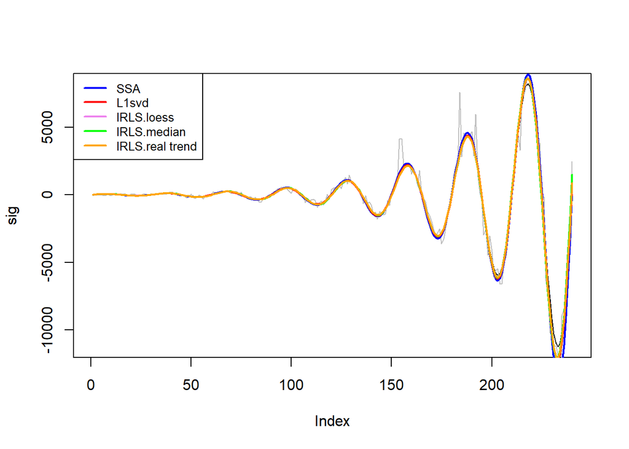

```r
plot(sig,type='l')
lines(ser,col='gray')
lines(trend.season,type='l',col='blue',lw=2)
lines(Pr.L1svd,type='l',col='red',lw=2)
lines(Pr0,type='l',col='violet',lw=2)
lines( Pr1,type='l',col='green',lw=2)
lines( Pr2,type='l',col='orange',lw=2)
legend('topleft', c("SSA","L1svd","IRLS.loess", "IRLS.median", "IRLS.real trend"),
       col=c("blue","red","violet","green","orange"), lty=1, cex=0.8, lw=2)
```

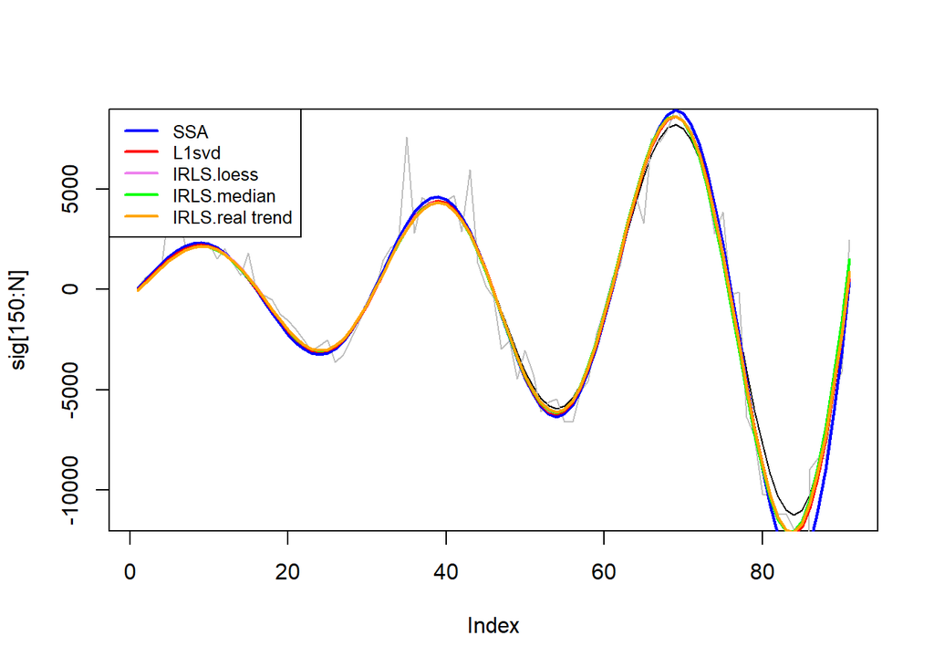

```r
plot(sig[150:N],type='l')
lines(ser[150:N],col='gray')
lines(trend.season[150:N],type='l',col='blue',lw=2)
lines(Pr.L1svd[150:N],type='l',col='red',lw=2)
lines(Pr0[150:N],type='l',col='violet',lw=2)
lines( Pr1[150:N],type='l',col='green',lw=2)
lines( Pr2[150:N],type='l',col='orange',lw=2)
legend('topleft', c("SSA","L1svd","IRLS.loess", "IRLS.median", "IRLS.real trend"),
       col=c("blue","red","violet","green","orange"), lty=1, cex=0.8, lw=2)
```

Видим, что L1svd и IRLS, использующий локальную регрессию для выделения тренда, оказываются наилучшими. Ошибка хоть и намного меньше ошибки стандартного SSA, но все еще достаточно большая. Ошибка метода IRLS со знанием истинного тренда оказалась также большой. Вероятно, проблема тогда не в выделении тренда, а в самой разделимости.